# Crime + Grime Index Development

Justin Elszasz

Tuesday, January 20, 2020

The purpose of this notebook is to create a neighborhood index that combines crime and cleanliness data. The index relies on [311 service request data](https://data.baltimorecity.gov/City-Services/311-Customer-Service-Requests/9agw-sxsr) and [Part 1 violent crime data](https://data.baltimorecity.gov/Public-Safety/BPD-Part-1-Victim-Based-Crime-Data/wsfq-mvij), both availble on Open Baltimore.

# Brief Description of The Index

The index primarily relies on counts of violent crime and service requests *per 1,000 residents*. This is done to remove the influence of population on the counts of these events. The per-capita metrics are then scaled to between 0 and 1 to build up the overall index.

All Part 1 crime types are used.

The SR types used are:

Illegal Dumping:

- HCD-Illegal Dumping
- SW-SIU Clean Up

Property Maintenance:

- HCD-Sanitation Property
- SW-Boarding
- SW-HGW
- SW-Cleaning

Right-of-Way Cleaning

- SW-Dirty Street
- SW-Dirty Alley

```r
knitr::opts_chunk$set(echo = T,
                      warning = F,
                      message = F,
                      include = T,
                      fig.width = 4,
                      fig.height = 3)
```

```r
library(tidyverse)
library(ggiteam)
library(lubridate)
library(readxl)
library(spdplyr)
library(leaflet)
library(RSocrata)
library(geojsonsf)
library(ggmap)
library(rgdal)
library(scales)
library(sf)
library(htmltools)


register_google("AIzaSyByyKUj4QaAlzNtPJPw-HkEEr7d4hTawO0")
```

```r
sr_query <- paste0("https://data.baltimorecity.gov/resource/9agw-sxsr.json",
                "?$where=",
                "((srtype like 'SW-Boarding' OR ",
                "srtype like 'SW-Cleaning' OR ",
                "srtype like 'SW-HGW' OR ",
                "srtype like 'SW-Dirty Alley' OR ",
                "srtype like 'SW-Dirty Street' OR ",
                "srtype like 'HCD-Illegal Dumping' OR ",
                "srtype like 'HCD-SIU' OR ",
                "srtype like 'SW-SIU Clean Up' OR ",
                "srtype like 'HCD-Sanitation Property') AND ",
                "date_extract_y(createddate)==2019)")

sr <- read.socrata(url = sr_query)

sr <- sr %>%
  mutate(
    latitude = as.numeric(latitude),
    longitude = as.numeric(longitude),
    neighborhood = toupper(neighborhood)

    )
```

```r
crime_query <- paste0("https://data.baltimorecity.gov/resource/wsfq-mvij.json?$where=",
                "(Description like 'HOMICIDE' OR ",
                "Description like 'SHOOTING' OR ",
                "Description like 'AGG. ASSAULT' OR ",
                "Description like 'RAPE' OR ",
                "contains(Description, 'ROBBERY')) AND ",
                "date_extract_y(crimedate)==2019")

crime <- read.socrata(crime_query)
```

```r
hoods.url <- "https://data.baltimorecity.gov/resource/h3fx-54q3.geojson"

# surely there is a better way, and i tried, but couldn't get anything else to work.
# from geojson to sf to spatial df. geojson_sp didn't work for me.
hoods <- geojson_sf(hoods.url)
hoods <- as_Spatial(hoods)
hoods <- spTransform(hoods, CRS("+init=epsg:4326"))
```

```r
# join acs data to hoods
hoods_pop <- read_excel("../data/raw/Neighborhood Pop.xlsx")
hoods@data <- left_join(hoods@data, hoods_pop, by = c("label" = "Name"))
```

```r
# bpd facilities to remove
facilities <- c(
  "300 E MADISON ST", # central booking
  "1400 E NORTH AVE", # district court
  "1900 ARGONNE DR", # northeastern
  "2200 W Cold Spring Ln", # northern
  "1000 N MOUNT ST", # western
  "5200 REISTERSTOWN RD ", # northwest
  "1600 EDISON HWY", # eastern
  "400 FONTHILL AVE", # southwest
  "0 CHERRY HILL RD", # southern
  "600 E FAYETTE ST", # central/hq
  "5700 EASTERN AVE", # southeast
  "2000 W BALTIMORE ST",  # bon secours
  "4000 DEEPWOOD RD", # loch raven va
  "300 N GAY ST", # juv booking
  "4900 EASTERN AV", # bayview
  "1800 ORLEANS ST", # jhh downtown
  "600 N WOLFE ST", # jhh downtown
  "0 S GREENE ST", # umd medical center
  "3400 N CALVERT ST" # union memorial
)
```

Population distribution of Baltimore neighborhoods.

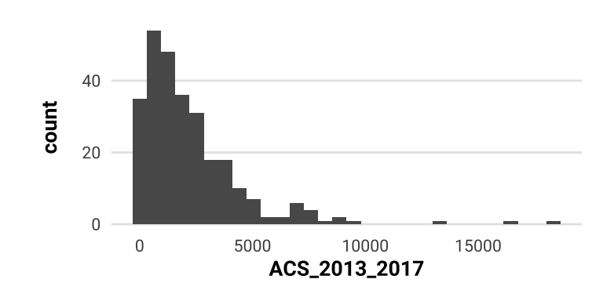

```r
hoods@data %>%
  ggplot(aes(ACS_2013_2017)) +
  geom_histogram() +
  theme_iteam_google_docs()
```

Tenth percentile for population:

```r
quantile(hoods$ACS_2013_2017, 0.1, na.rm = T)
```

```
     10%
174.7548
```

# Analysis

```r
crime_labeled <- crime %>%
  filter(
    !is.na(latitude),
    !(location %in% facilities)
    ) %>%
  st_as_sf(coords = c("longitude", "latitude"), crs = 4326) %>%
  st_join(st_as_sf(hoods), join = st_within, left = F)

crime_hood_counts <- crime_labeled %>%
  data.frame() %>%
  count(description, label) %>%
  spread(key = description, value = n) %>%
  replace(is.na(.), 0) %>%
  transmute(
    label = label,
    agg_assault = `AGG. ASSAULT`,
    rape = RAPE,
    homicide_shootings = HOMICIDE + SHOOTING,
    robbery = `ROBBERY - COMMERCIAL` +
      `ROBBERY - CARJACKING` +
      `ROBBERY - RESIDENCE` +
      `ROBBERY - STREET`)
```

```r
sr_labeled <- sr %>%
  filter(
    !is.na(latitude)
    ) %>%
  st_as_sf(coords = c("longitude", "latitude"), crs = 4326) %>%
  st_join(st_as_sf(hoods), join = st_within, left = F)

sr_hood_counts <- sr_labeled %>%
  data.frame() %>%
  count(srtype, label) %>%
  spread(key = srtype, value = n) %>%
  replace(is.na(.), 0) %>%
  transmute(
    label = label,
    illegal_dumping = `HCD-Illegal Dumping` + `SW-SIU Clean Up`,
    property_maintenance = `HCD-Sanitation Property` +
      `SW-Boarding` +
      `SW-Cleaning` +
      `SW-HGW`,
    right_of_way = `SW-Dirty Street` + `SW-Dirty Alley`
  )
```

```r
# to per 1,000 residents
to_per_capita <- function(x){1000 * x / hoods$ACS_2013_2017}

hood_metrics <- hoods

hood_metrics@data <- hood_metrics@data %>%
  select(-acres,
         -nbrdesc,
         -shape_leng,
         -shape_area,
         -color_2,
         -Decennial2010)

hood_metrics@data <- hood_metrics@data %>%
  left_join(
    crime_hood_counts,
    by = "label") %>%
  left_join(
    sr_hood_counts,
    by = "label"
  ) %>%
  mutate_at(
    vars(
      illegal_dumping,
      property_maintenance,
      right_of_way,
      homicide_shootings,
      robbery,
      agg_assault,
      rape),
    list(per_1000_res = to_per_capita))
```

Distribution of per capita rates of crime and service requests:

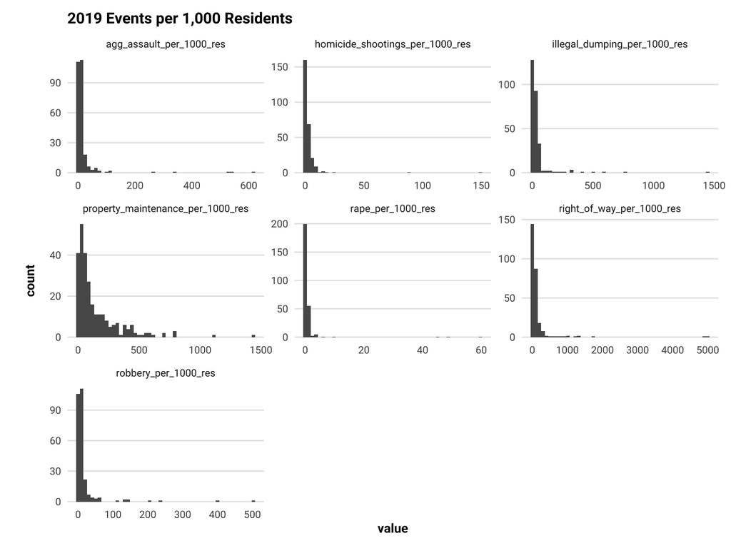

```r
hood_metrics@data %>%
  select(
    label,
    illegal_dumping_per_1000_res,
    property_maintenance_per_1000_res,
    right_of_way_per_1000_res,
    homicide_shootings_per_1000_res,
    robbery_per_1000_res,
    agg_assault_per_1000_res,
    rape_per_1000_res
  ) %>%
  pivot_longer(-label) %>%
  ggplot(aes(value)) +
  facet_wrap(~name, scales = "free") +
  geom_histogram(bins = 50) +
  theme_iteam_google_docs() +
  labs(title = "2019 Events per 1,000 Residents")
```

In all cases, outlier neighborhoods with very small populations skew data.

Try removing neighborhoods with less than 150 residents (10% of neighborhoods). These are typically parks, industrial areas, etc.

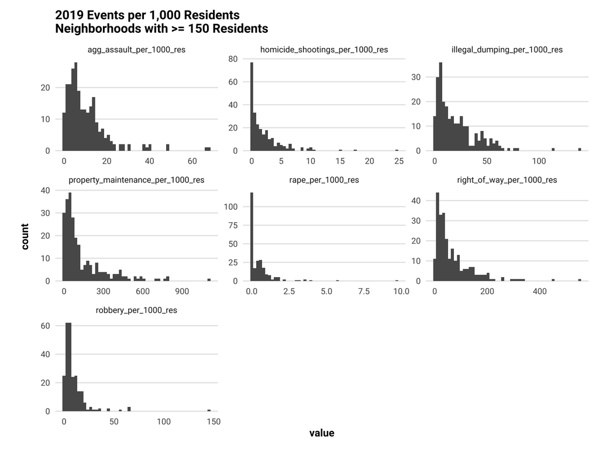

```r
hood_metrics@data %>%
  filter(ACS_2013_2017 >= 150) %>%
  select(
    label,
    illegal_dumping_per_1000_res,
    property_maintenance_per_1000_res,
    right_of_way_per_1000_res,
    homicide_shootings_per_1000_res,
    robbery_per_1000_res,
    agg_assault_per_1000_res,
    rape_per_1000_res
  ) %>%
  pivot_longer(-label) %>%
  ggplot(aes(value)) +
  facet_wrap(~name, scales = "free") +
  geom_histogram(bins = 50) +
    theme_iteam_google_docs() +
  labs(title = "2019 Events per 1,000 Residents\nNeighborhoods with >= 150 Residents")
```

Going forward, removing neighborhoods with less than 150 residents.

```r
hood_metrics_over150 <- subset(hood_metrics, hood_metrics$ACS_2013_2017 > 150)
```

Number of neighborhoods with at least one homicide or shooting:

```r
hood_metrics_over150@data %>%
  count(homicide_shootings >= 1)
```

| homicide_shootings >= 1 | n |
| --- | --- |
| FALSE | 73 |
| TRUE | 174 |
| NA | 4 |

Will likely assign 1 to neighborhoods with at least 1 homicide or shooting, 0 to all others. This will ensure neighborhoods with gun violence are given precedence.

# Building The Index

All parameters will be scaled to between 0 and 1 because variables are on different scales.

```r
# scale per capita
scale_index <- function(x){rescale(x, to = c(0,1))}

hood_metrics_over150@data <- hood_metrics_over150@data %>%
  mutate(
    homicide_shootings_index = ifelse(homicide_shootings > 0, 1, 0),
    rape_index = ifelse(rape > 0, 1, 0)) %>%
  mutate_at(
    vars(
      illegal_dumping_per_1000_res,
      property_maintenance_per_1000_res,
      right_of_way_per_1000_res,
      homicide_shootings_per_1000_res,
      robbery_per_1000_res,
      agg_assault_per_1000_res,
      rape_per_1000_res),
    list(index = scale_index)
    )
```

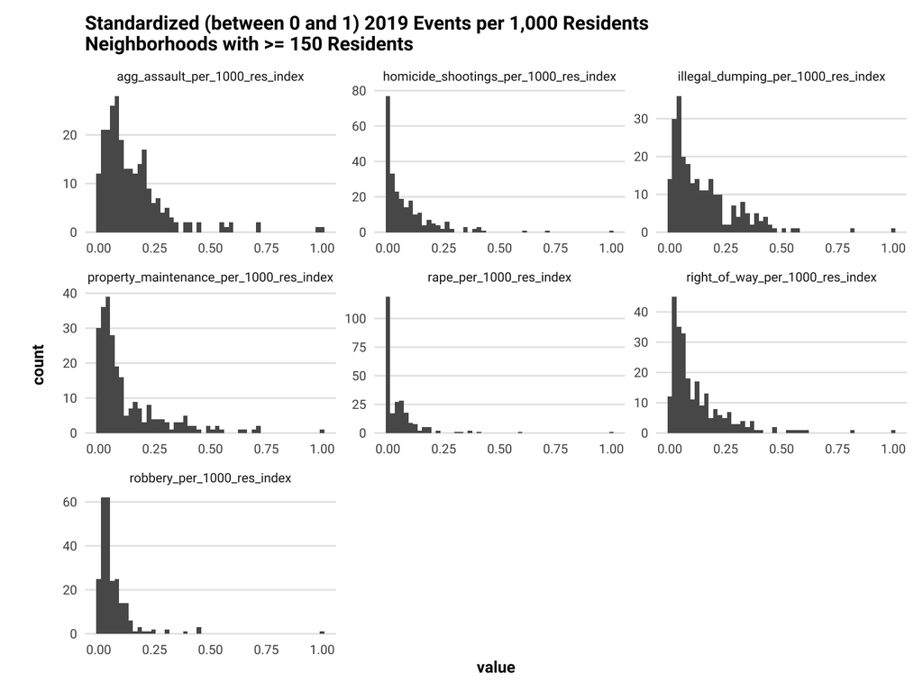

```r
# plot rescaled data
hood_metrics_over150@data %>%
  select(
    label,
    illegal_dumping_per_1000_res_index,
    property_maintenance_per_1000_res_index,
    right_of_way_per_1000_res_index,
    homicide_shootings_per_1000_res_index,
    robbery_per_1000_res_index,
    agg_assault_per_1000_res_index,
    rape_per_1000_res_index
  ) %>%
  pivot_longer(-label) %>%
  ggplot(aes(value)) +
  facet_wrap(~name, scales = "free") +
  geom_histogram(bins = 50) +
    theme_iteam_google_docs() +
  labs(title = "Standardized (between 0 and 1) 2019 Events per 1,000 Residents\nNeighborhoods with >= 150 Residents")
```

**Again, all metrics have been scaled to between 0 and 1.** Combine crime metrics into a homicide and shooting parameter (0 if none in neighborhood, 1 if at least 1) and an “other violent crime” parameter where:

$$HomicideShootingsIndex = \begin{cases}
1 & \text{if $N_{homicides}+N_{shootings} > 0$ } \\
0 & \text{otherwise} \end{cases}$$

$$OtherViolentCrimeIndex = \frac{1}{3}(RapeIndex+ AggAssaultIndex + RobberyIndex)$$

Combining the two crime indices:

$$CrimeIndex = \frac{1}{2} (HomicideShootingsIndex + OtherViolentCrimeIndex)$$

```r
# create combined index
hood_metrics_over150@data <- hood_metrics_over150@data %>%
  rowwise() %>%
  mutate(
    other_violent_crime_index =
      mean(
        c(rape_per_1000_res_index,
          agg_assault_per_1000_res_index,
          robbery_per_1000_res_index),
        na.rm = T),
    grime_index = mean(
      c(illegal_dumping_per_1000_res_index,
        property_maintenance_per_1000_res_index,
        right_of_way_per_1000_res_index),
      na.rm = T)
  ) %>%
  ungroup() %>%
  mutate(crime_index = 0.5 * homicide_shootings_index +
           0.5 * other_violent_crime_index,
         crime_grime_index = 0.5 * crime_index + 0.5 * grime_index)

hood_metrics_over150@data <- hood_metrics_over150@data %>%
  mutate(crime_grime_index_quadrature = sqrt(crime_index^2 + grime_index^2))
```

Now creating the “grime” index:

$$GrimeIndex = \frac{1}{3}(IllegalDumpingIndex + PropMaintenanceIndex + RightOfWayIndex)$$
Combine into a single index:

$$CrimeGrimeIndex = \frac{1}{2}(CrimeIndex +GrimeIndex)$$

# Just Show Me The Results

```r
# base_map <- get_map(
#   location=c(lon = -76.61, lat = 39.3),
#   zoom=12,
#   maptype = 'toner-lite',
#   source = 'stamen'
#   )
#
# ggmap(base_map) +
#   # geom_point(
#   #   data = repeat_offender_locations %>%
#   #     filter(!is.na(lon),
#   #            n >= 3),
#   #   aes(x = lon, y = lat),
#   #   color = "blue",
#   #   size = 2
#   # )
#   geom_polygon(
#     data = fortify(hood_metrics_over150) %>%
#       filter(!is.na(crime_grime_index)),
#     aes(x = long, y = lat, group = group, fill = crime_grime_index),
#     alpha = 0.9,color = "black"
#   )# +
#   # scale_fill_viridis_c(na.value = NA,
#   #                      #values = rescale(c(0, 20, 70), c(0,1)),
#   #                      option = "plasma",
#   #                      guide_colorbar(title = "Annual DV Incidents\nper 1,000 Residents"))
#   #
```

```r
hoods@data <- hoods@data %>%
  left_join(
    hood_metrics_over150@data %>% select(-ACS_2013_2017),
    by = "label"
  )
```

```r
# color palette for map
pal <-  colorNumeric("viridis", domain = hoods$crime_grime_index)

# labels
map_labels <- paste0(
  "<b>",hoods$label, "</b><br>",
  "Population: ", round(hoods$ACS_2013_2017, 0), "<br>",
  "Crime & Grime Index: ", round(hoods$crime_grime_index, 2), "<br>",
  "Crime Index: ", round(hoods$crime_index, 2), "<br>",
  "Grime Index: ", round(hoods$grime_index, 2), "<br>",
  "<br><b>2019 Crime</b><br>",
  "Homicides + Shootings: ", hoods$homicide_shootings, "<br>",
  "Rape: ", hoods$rape, "<br>",
  "Aggravated Assault: ", hoods$agg_assault, "<br>",
  "Robbery: ", hoods$robbery, "<br>",
  "<br><b>2019 Service Requests</b><br>",
  "Illegal Dumping SRs: ", hoods$illegal_dumping, "<br>",
  "Property Maintenance SRs: ", hoods$property_maintenance, "<br>",
  "Right-of-Way SRs: ", hoods$right_of_way, "<br>"
)
```

## Distribution of Indexes

Because of the homicide and shooting index being 1 for neighborhoods with at least one homicide or shooting and 0 for all others, the distribution is bifurcated into neighborhoods with and without shootings.

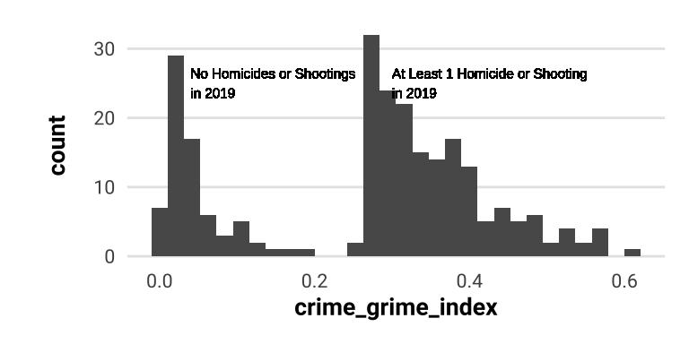

```r
hoods@data %>%
  ggplot(aes(crime_grime_index)) +
  geom_histogram() +
  theme_iteam_google_docs() +
  geom_text(aes(0.3, 25,
                label="At Least 1 Homicide or Shooting\nin 2019"), size = 2, hjust = 0) +
  geom_text(aes(0.04, 25,
                label="No Homicides or Shootings\nin 2019"), size = 2, hjust = 0)
```

## The List, In Order of Descending Crime-Grime Index

Some neighborhoods with very small populations still sneak onto the list because we only used 150 as the cut-off, but those can be manually dropped if not interested.

```r
the_list <- hoods@data %>%
  arrange(desc(crime_grime_index)) %>%
  select(-acres, -nbrdesc, -shape_leng, -shape_area, -color_2, -Decennial2010) %>%
  rename(neighborhood = label,
         population_acs_2013_2017 = ACS_2013_2017)

write_csv(the_list, "../data/processed/crime_grime_index_v1.csv")

the_list
```

| neighborhood | population_acs_2013_2017 | agg_assault | rape | homicide_shootings | robbery | illegal_dumping | property_maintenance | right_of_way | illegal_dumping_per_1000_res | property_maintenance_per_1000_res | right_of_way_per_1000_res | homicide_shootings_per_1000_res | robbery_per_1000_res | agg_assault_per_1000_res | rape_per_1000_res | homicide_shootings_index | rape_index | illegal_dumping_per_1000_res_index | property_maintenance_per_1000_res_index | right_of_way_per_1000_res_index | homicide_shootings_per_1000_res_index | robbery_per_1000_res_index | agg_assault_per_1000_res_index | rape_per_1000_res_index | other_violent_crime_index | grime_index | crime_index | crime_grime_index | crime_grime_index_quadrature |
| --- | --- | --- | --- | --- | --- | --- | --- | --- | --- | --- | --- | --- | --- | --- | --- | --- | --- | --- | --- | --- | --- | --- | --- | --- | --- | --- | --- | --- | --- |
| Wilhelm Park | 280.486391 | 5 | 0 | 1 | 5 | 39 | 129 | 89 | 139.0441792 | 459.915362 | 317.3059473 | 3.5652354 | 17.8261768 | 17.8261768 | 0.00000000 | 1 | 0 | 1.000000000 | 0.413702293 | 0.573786917 | 0.144822226 | 0.122592437 | 0.262698080 | 0.000000000 | 0.128430173 | 0.662496403 | 0.5642150863 | 0.613355745 | 0.870195465 |
| Broadway East | 4247.525500 | 69 | 2 | 40 | 29 | 227 | 4722 | 754 | 53.4428810 | 1111.706098 | 177.5151203 | 9.4172478 | 6.8275046 | 16.2447524 | 0.47086239 | 1 | 1 | 0.384358996 | 1.000000000 | 0.320524102 | 0.382534853 | 0.046953446 | 0.239393186 | 0.048572531 | 0.111639721 | 0.568294366 | 0.5558198605 | 0.562057113 | 0.794917734 |
| Carrollton Ridge | 3492.676226 | 98 | 2 | 35 | 65 | 156 | 2789 | 1022 | 44.6648902 | 798.528068 | 292.6122932 | 10.0209689 | 18.6103709 | 28.0587130 | 0.57262680 | 1 | 1 | 0.321228047 | 0.718290625 | 0.529048757 | 0.407058408 | 0.127985420 | 0.413491358 | 0.059070194 | 0.200182324 | 0.522855810 | 0.6000911619 | 0.561473486 | 0.795919343 |
| Pulaski Industrial Area | 206.313062 | 14 | 2 | 0 | 30 | 16 | 69 | 114 | 77.5520456 | 334.443197 | 552.5583252 | 0.0000000 | 145.4100856 | 67.8580399 | 9.69400570 | 0 | 1 | 0.557751113 | 0.300837782 | 1.000000000 | 0.000000000 | 1.000000000 | 1.000000000 | 1.000000000 | 1.000000000 | 0.619529632 | 0.5000000000 | 0.559764816 | 0.796126224 |
| Kresson | 507.041324 | 9 | 0 | 1 | 9 | 58 | 134 | 167 | 114.3890986 | 264.278262 | 329.3617149 | 1.9722258 | 17.7500325 | 17.7500325 | 0.00000000 | 1 | 0 | 0.822681678 | 0.237723138 | 0.595628676 | 0.080113122 | 0.122068785 | 0.261575969 | 0.000000000 | 0.127881585 | 0.552011164 | 0.5639407924 | 0.557975978 | 0.789142283 |
| Penn North | 1858.490554 | 73 | 1 | 19 | 40 | 91 | 1332 | 384 | 48.9644673 | 716.710665 | 206.6192907 | 10.2233503 | 21.5228428 | 39.2791881 | 0.53807107 | 1 | 1 | 0.352150429 | 0.644694372 | 0.373252913 | 0.415279274 | 0.148014787 | 0.578843540 | 0.055505545 | 0.260787957 | 0.456699238 | 0.6303939786 | 0.543546608 | 0.778441239 |
| Orangeville | 228.868324 | 11 | 0 | 2 | 10 | 18 | 28 | 70 | 78.6478429 | 122.341089 | 305.8527225 | 8.7386492 | 43.6932461 | 48.0625707 | 0.00000000 | 1 | 0 | 0.565632042 | 0.110048051 | 0.553036800 | 0.354969730 | 0.300482913 | 0.708281152 | 0.000000000 | 0.336254688 | 0.409572298 | 0.6681273441 | 0.538849821 | 0.783673156 |
| East Baltimore Midway | 2758.825000 | 85 | 6 | 13 | 46 | 156 | 1543 | 618 | 56.5458121 | 559.296077 | 224.0084094 | 4.7121510 | 16.6737651 | 30.8102181 | 2.17483893 | 1 | 1 | 0.406675148 | 0.503097067 | 0.404757249 | 0.191410701 | 0.114667184 | 0.454039317 | 0.224348839 | 0.264351780 | 0.438176488 | 0.6321758901 | 0.535176189 | 0.769184627 |
| Milton-Montford | 893.654599 | 20 | 1 | 22 | 16 | 39 | 627 | 236 | 43.6410220 | 701.613353 | 264.0841330 | 24.6180124 | 17.9040090 | 22.3800113 | 1.11900056 | 1 | 1 | 0.313864430 | 0.631114064 | 0.477363519 | 1.000000000 | 0.123127697 | 0.329806332 | 0.115432216 | 0.189455415 | 0.474114004 | 0.5947277077 | 0.534420856 | 0.760582103 |
| McElderry Park | 3594.680056 | 78 | 2 | 24 | 54 | 207 | 962 | 1608 | 57.5850971 | 267.617698 | 447.3277107 | 6.6765330 | 15.0221992 | 21.6987322 | 0.55637775 | 1 | 1 | 0.414149642 | 0.240727021 | 0.809350855 | 0.271205201 | 0.103309197 | 0.319766563 | 0.057393999 | 0.160156586 | 0.488075840 | 0.5800782932 | 0.534077066 | 0.758095542 |

[output cut: 268 more lines]